# Credit Card Users Churn Prediction

## Problem Statement

### Business Context

The Thera bank recently saw a steep decline in the number of users of their credit card, credit cards are a good source of income for banks because of different kinds of fees charged by the banks like annual fees, balance transfer fees, and cash advance fees, late payment fees, foreign transaction fees, and others. Some fees are charged to every user irrespective of usage, while others are charged under specified circumstances.

Customers’ leaving credit cards services would lead bank to loss, so the bank wants to analyze the data of customers and identify the customers who will leave their credit card services and reason for same – so that bank could improve upon those areas

You as a Data scientist at Thera bank need to come up with a classification model that will help the bank improve its services so that customers do not renounce their credit cards

### Data Description

- CLIENTNUM: Client number. Unique identifier for the customer holding the account
- Attrition_Flag: Internal event (customer activity) variable - if the account is closed then "Attrited Customer" else "Existing Customer"
- Customer_Age: Age in Years
- Gender: Gender of the account holder
- Dependent_count: Number of dependents
- Education_Level: Educational Qualification of the account holder - Graduate, High School, Unknown, Uneducated, College(refers to college student), Post-Graduate, Doctorate
- Marital_Status: Marital Status of the account holder
- Income_Category: Annual Income Category of the account holder
- Card_Category: Type of Card
- Months_on_book: Period of relationship with the bank (in months)
- Total_Relationship_Count: Total no. of products held by the customer
- Months_Inactive_12_mon: No. of months inactive in the last 12 months
- Contacts_Count_12_mon: No. of Contacts in the last 12 months
- Credit_Limit: Credit Limit on the Credit Card
- Total_Revolving_Bal: Total Revolving Balance on the Credit Card
- Avg_Open_To_Buy: Open to Buy Credit Line (Average of last 12 months)
- Total_Amt_Chng_Q4_Q1: Change in Transaction Amount (Q4 over Q1)
- Total_Trans_Amt: Total Transaction Amount (Last 12 months)
- Total_Trans_Ct: Total Transaction Count (Last 12 months)
- Total_Ct_Chng_Q4_Q1: Change in Transaction Count (Q4 over Q1)
- Avg_Utilization_Ratio: Average Card Utilization Ratio

#### What Is a Revolving Balance?

- If we don't pay the balance of the revolving credit account in full every month, the unpaid portion carries over to the next month. That's called a revolving balance

##### What is the Average Open to buy?

- 'Open to Buy' means the amount left on your credit card to use. Now, this column represents the average of this value for the last 12 months.

##### What is the Average utilization Ratio?

- The Avg_Utilization_Ratio represents how much of the available credit the customer spent. This is useful for calculating credit scores.

##### Relation b/w Avg_Open_To_Buy, Credit_Limit and Avg_Utilization_Ratio:

- ( Avg_Open_To_Buy / Credit_Limit ) + Avg_Utilization_Ratio = 1

### **Please read the instructions carefully before starting the project.**

This is a commented Jupyter IPython Notebook file in which all the instructions and tasks to be performed are mentioned.

- Blanks '**___**' are provided in the notebook that needs to be filled with an appropriate code to get the correct result. With every '**___**' blank, there is a comment that briefly describes what needs to be filled in the blank space.
- Identify the task to be performed correctly, and only then proceed to write the required code.
- Fill the code wherever asked by the commented lines like "# write your code here" or "# complete the code". Running incomplete code may throw error.
- Please run the codes in a sequential manner from the beginning to avoid any unnecessary errors.
- Add the results/observations (wherever mentioned) derived from the analysis in the presentation and submit the same.

## Importing necessary libraries

```python
# Installing the libraries with the specified version.
# uncomment and run the following line if Google Colab is being used
!pip install scikit-learn==1.3.1 seaborn==0.13.1 matplotlib==3.8.0 numpy==1.25.2 pandas==2.2.2 imbalanced-learn==0.10.1 xgboost==2.0.3 -q --user
```

**Note**: *After running the above cell, kindly restart the notebook kernel and run all cells sequentially from the start again*.

```python
# Libraries to help with reading and manipulating data
import pandas as pd
import numpy as np

# libaries to help with data visualization
import matplotlib.pyplot as plt
import seaborn as sns

# to scale the data using z-score
from sklearn.preprocessing import StandardScaler

# to suppress warnings
import warnings
warnings.filterwarnings("ignore")
# to split data into training and test sets
from sklearn.model_selection import train_test_split

# To do hyperparameter tuning
from sklearn.model_selection import RandomizedSearchCV

# to build decision tree model
from sklearn.tree import DecisionTreeClassifier
from sklearn import tree

# to tune different models
from sklearn.model_selection import GridSearchCV

# to compute classification metrics
from sklearn.metrics import (
    confusion_matrix,
    accuracy_score,
    recall_score,
    precision_score,
    f1_score,
    roc_auc_score,
    ConfusionMatrixDisplay,
)

from sklearn.model_selection import train_test_split, StratifiedKFold, cross_val_score

# To impute missing values
from sklearn.impute import SimpleImputer
from sklearn import metrics

# To be used for data scaling and one hot encoding
from sklearn.preprocessing import StandardScaler, MinMaxScaler, OneHotEncoder
```

## Loading the dataset

```python
# Mounting Google Colab drive
from google.colab import drive
drive.mount('/gdrive')
%cd /gdrive/MyDrive
```

```
Mounted at /gdrive
/gdrive/MyDrive
```

```python
# loading the dataset
df = pd.read_csv("/gdrive/MyDrive/Python/BankChurners.csv")
```

```python
# copying the data to another variable to avoid any changes to original data
data = df.copy()
```

## Data Overview

### Checking the shape of the dataset.

```python
#Checking the shape of the dataset
data.shape
```

```
(10127, 21)
```

- The dataset has 10127 rows and 21 columns

### Viewing the first and last 5 rows of the dataset

```python
# viewing the first 5 rows of the data
data.head()
```

|  | CLIENTNUM | Attrition_Flag | Customer_Age | Gender | Dependent_count | Education_Level | Marital_Status | Income_Category | Card_Category | Months_on_book | ... | Months_Inactive_12_mon | Contacts_Count_12_mon | Credit_Limit | Total_Revolving_Bal | Avg_Open_To_Buy | Total_Amt_Chng_Q4_Q1 | Total_Trans_Amt | Total_Trans_Ct | Total_Ct_Chng_Q4_Q1 | Avg_Utilization_Ratio |
| --- | --- | --- | --- | --- | --- | --- | --- | --- | --- | --- | --- | --- | --- | --- | --- | --- | --- | --- | --- | --- | --- |
| 0 | 768805383 | Existing Customer | 45 | M | 3 | High School | Married | $60K - $80K | Blue | 39 | ... | 1 | 3 | 12691.0 | 777 | 11914.0 | 1.335 | 1144 | 42 | 1.625 | 0.061 |
| 1 | 818770008 | Existing Customer | 49 | F | 5 | Graduate | Single | Less than $40K | Blue | 44 | ... | 1 | 2 | 8256.0 | 864 | 7392.0 | 1.541 | 1291 | 33 | 3.714 | 0.105 |
| 2 | 713982108 | Existing Customer | 51 | M | 3 | Graduate | Married | $80K - $120K | Blue | 36 | ... | 1 | 0 | 3418.0 | 0 | 3418.0 | 2.594 | 1887 | 20 | 2.333 | 0.000 |
| 3 | 769911858 | Existing Customer | 40 | F | 4 | High School | NaN | Less than $40K | Blue | 34 | ... | 4 | 1 | 3313.0 | 2517 | 796.0 | 1.405 | 1171 | 20 | 2.333 | 0.760 |
| 4 | 709106358 | Existing Customer | 40 | M | 3 | Uneducated | Married | $60K - $80K | Blue | 21 | ... | 1 | 0 | 4716.0 | 0 | 4716.0 | 2.175 | 816 | 28 | 2.500 | 0.000 |

5 rows × 21 columns

```python
# viewing the last 5 rows of the data
data.tail(5)
```

|  | CLIENTNUM | Attrition_Flag | Customer_Age | Gender | Dependent_count | Education_Level | Marital_Status | Income_Category | Card_Category | Months_on_book | ... | Months_Inactive_12_mon | Contacts_Count_12_mon | Credit_Limit | Total_Revolving_Bal | Avg_Open_To_Buy | Total_Amt_Chng_Q4_Q1 | Total_Trans_Amt | Total_Trans_Ct | Total_Ct_Chng_Q4_Q1 | Avg_Utilization_Ratio |
| --- | --- | --- | --- | --- | --- | --- | --- | --- | --- | --- | --- | --- | --- | --- | --- | --- | --- | --- | --- | --- | --- |
| 10122 | 772366833 | Existing Customer | 50 | M | 2 | Graduate | Single | $40K - $60K | Blue | 40 | ... | 2 | 3 | 4003.0 | 1851 | 2152.0 | 0.703 | 15476 | 117 | 0.857 | 0.462 |
| 10123 | 710638233 | Attrited Customer | 41 | M | 2 | NaN | Divorced | $40K - $60K | Blue | 25 | ... | 2 | 3 | 4277.0 | 2186 | 2091.0 | 0.804 | 8764 | 69 | 0.683 | 0.511 |
| 10124 | 716506083 | Attrited Customer | 44 | F | 1 | High School | Married | Less than $40K | Blue | 36 | ... | 3 | 4 | 5409.0 | 0 | 5409.0 | 0.819 | 10291 | 60 | 0.818 | 0.000 |
| 10125 | 717406983 | Attrited Customer | 30 | M | 2 | Graduate | NaN | $40K - $60K | Blue | 36 | ... | 3 | 3 | 5281.0 | 0 | 5281.0 | 0.535 | 8395 | 62 | 0.722 | 0.000 |
| 10126 | 714337233 | Attrited Customer | 43 | F | 2 | Graduate | Married | Less than $40K | Silver | 25 | ... | 2 | 4 | 10388.0 | 1961 | 8427.0 | 0.703 | 10294 | 61 | 0.649 | 0.189 |

5 rows × 21 columns

### Checking the attribute types

```python
# checking datatypes and number of non-null values for each column
data.info()
```

```
<class 'pandas.core.frame.DataFrame'>
RangeIndex: 10127 entries, 0 to 10126
Data columns (total 21 columns):
 #   Column                    Non-Null Count  Dtype
---  ------                    --------------  -----
 0   CLIENTNUM                 10127 non-null  int64
 1   Attrition_Flag            10127 non-null  object
 2   Customer_Age              10127 non-null  int64
 3   Gender                    10127 non-null  object
 4   Dependent_count           10127 non-null  int64
 5   Education_Level           8608 non-null   object
 6   Marital_Status            9378 non-null   object
 7   Income_Category           10127 non-null  object
 8   Card_Category             10127 non-null  object
 9   Months_on_book            10127 non-null  int64
 10  Total_Relationship_Count  10127 non-null  int64
 11  Months_Inactive_12_mon    10127 non-null  int64
 12  Contacts_Count_12_mon     10127 non-null  int64
 13  Credit_Limit              10127 non-null  float64
 14  Total_Revolving_Bal       10127 non-null  int64
 15  Avg_Open_To_Buy           10127 non-null  float64
 16  Total_Amt_Chng_Q4_Q1      10127 non-null  float64
 17  Total_Trans_Amt           10127 non-null  int64
 18  Total_Trans_Ct            10127 non-null  int64
 19  Total_Ct_Chng_Q4_Q1       10127 non-null  float64
 20  Avg_Utilization_Ratio     10127 non-null  float64
dtypes: float64(5), int64(10), object(6)
memory usage: 1.6+ MB
```

- There are 15 numerical and 6 categorical variables in the data frame

```python
# checking missing values in the data
data.isna().sum()
```

|  | 0 |
| --- | --- |
| CLIENTNUM | 0 |
| Attrition_Flag | 0 |
| Customer_Age | 0 |
| Gender | 0 |
| Dependent_count | 0 |
| Education_Level | 1519 |
| Marital_Status | 749 |
| Income_Category | 0 |
| Card_Category | 0 |
| Months_on_book | 0 |
| Total_Relationship_Count | 0 |
| Months_Inactive_12_mon | 0 |
| Contacts_Count_12_mon | 0 |
| Credit_Limit | 0 |
| Total_Revolving_Bal | 0 |
| Avg_Open_To_Buy | 0 |
| Total_Amt_Chng_Q4_Q1 | 0 |
| Total_Trans_Amt | 0 |
| Total_Trans_Ct | 0 |
| Total_Ct_Chng_Q4_Q1 | 0 |
| Avg_Utilization_Ratio | 0 |

**dtype:** int64

- Missing data is observed for Education_Level and Marital_Status columns which will need imputation ahead.

```python
# checking for duplicate values
data.duplicated().sum()
```

```
0
```

```python
# checking the number of unique values in each column
data.nunique()
```

|  | 0 |
| --- | --- |
| CLIENTNUM | 10127 |
| Attrition_Flag | 2 |
| Customer_Age | 45 |
| Gender | 2 |
| Dependent_count | 6 |
| Education_Level | 6 |
| Marital_Status | 3 |
| Income_Category | 6 |
| Card_Category | 4 |
| Months_on_book | 44 |
| Total_Relationship_Count | 6 |
| Months_Inactive_12_mon | 7 |
| Contacts_Count_12_mon | 7 |
| Credit_Limit | 6205 |
| Total_Revolving_Bal | 1974 |
| Avg_Open_To_Buy | 6813 |
| Total_Amt_Chng_Q4_Q1 | 1158 |
| Total_Trans_Amt | 5033 |
| Total_Trans_Ct | 126 |
| Total_Ct_Chng_Q4_Q1 | 830 |
| Avg_Utilization_Ratio | 964 |

**dtype:** int64

```python
#check unqiue values of Categorical Variables
print(f"Unique values in 'Gender':",df['Gender'].unique())
print(f"Unique values in 'Education':",df['Education_Level'].unique())
print(f"Unique values in 'MaritalStatus':",df['Marital_Status'].unique())
print(f"Unique values in 'IncomeCategory':",df['Income_Category'].unique())

#check unique values in numerical columns with lesser unique values
print(f"Unique values in 'DependentCount': ",df['Dependent_count'].unique())
print(f"Unique values in 'Total_Relationship_Count': ",df['Total_Relationship_Count'].unique())
print(f"Unique values in 'Month_Inactive_12_mon': ",df['Months_Inactive_12_mon'].unique())
print(f"Unique values in 'Contacts_Count_12_mon ': ",df['Contacts_Count_12_mon'].unique())
```

```
Unique values in 'Gender': ['M' 'F']
Unique values in 'Education': ['High School' 'Graduate' 'Uneducated' nan 'College' 'Post-Graduate'
 'Doctorate']
Unique values in 'MaritalStatus': ['Married' 'Single' nan 'Divorced']
Unique values in 'IncomeCategory': ['$60K - $80K' 'Less than $40K' '$80K - $120K' '$40K - $60K' '$120K +'
 'abc']
Unique values in 'DependentCount':  [3 5 4 2 0 1]
Unique values in 'Total_Relationship_Count':  [5 6 4 3 2 1]
Unique values in 'Month_Inactive_12_mon':  [1 4 2 3 6 0 5]
Unique values in 'Contacts_Count_12_mon ':  [3 2 0 1 4 5 6]
```

- From here we an infer that DependentCount ,Total_Relationship_Count, Month_Inactive_12_mon & Contacts_Count_12_mon as label encoded categorial columns -In the income category , an anamolous value 'abc' is seen. We can infer this as undisclosed where customer did not chose to mention his income.We can treat it as a seperate category and for better meaning,update the value from 'abc' to 'Undisclosed'

```python
#Print count of rows having Income Category value as 'abc'
print( data['Income_Category'].value_counts().get('abc',0))
```

```
1112
```

```python
#Checking statistical Summary of the data frame
data.describe().T
```

|  | count | mean | std | min | 25% | 50% | 75% | max |
| --- | --- | --- | --- | --- | --- | --- | --- | --- |
| Customer_Age | 10127.0 | 46.325960 | 8.016814 | 26.0 | 41.000 | 46.000 | 52.000 | 73.000 |
| Months_on_book | 10127.0 | 35.928409 | 7.986416 | 13.0 | 31.000 | 36.000 | 40.000 | 56.000 |
| Credit_Limit | 10127.0 | 8631.953698 | 9088.776650 | 1438.3 | 2555.000 | 4549.000 | 11067.500 | 34516.000 |
| Total_Revolving_Bal | 10127.0 | 1162.814061 | 814.987335 | 0.0 | 359.000 | 1276.000 | 1784.000 | 2517.000 |
| Avg_Open_To_Buy | 10127.0 | 7469.139637 | 9090.685324 | 3.0 | 1324.500 | 3474.000 | 9859.000 | 34516.000 |
| Total_Amt_Chng_Q4_Q1 | 10127.0 | 0.759941 | 0.219207 | 0.0 | 0.631 | 0.736 | 0.859 | 3.397 |
| Total_Trans_Amt | 10127.0 | 4404.086304 | 3397.129254 | 510.0 | 2155.500 | 3899.000 | 4741.000 | 18484.000 |
| Total_Trans_Ct | 10127.0 | 64.858695 | 23.472570 | 10.0 | 45.000 | 67.000 | 81.000 | 139.000 |
| Total_Ct_Chng_Q4_Q1 | 10127.0 | 0.712222 | 0.238086 | 0.0 | 0.582 | 0.702 | 0.818 | 3.714 |
| Avg_Utilization_Ratio | 10127.0 | 0.274894 | 0.275691 | 0.0 | 0.023 | 0.176 | 0.503 | 0.999 |

- The DataFrame has 10127 rows and 21 colums
- 15 colums are Numerical type and 6 are of Categorical(Object Type)
- Out of the 15 numerical columns, 4 more columns can be inferred as label encded categorical colummns
  - DependentCount ,
  - Total_Relationship_Count,
  - Month_Inactive_12_mon
  - Contacts_Count_12_mon
- Categorial Coulumns consist of
  - 2 Unique(Attrition Flags)
  - 2 Unique (Genders),
  - 6 unique (Education Levels),
  - 3 Unique (Marital status),
  - 6 unique(Income Category),
  - 4 unique (Cards Category).
- Missing data is observed for
  - Education_Level(1519 records),
  - Marital_Status(749 records) columns
- 16% if Customers have attrited (1627 out of 10127)

## Exploratory Data Analysis (EDA)

- EDA is an important part of any project involving data.
- It is important to investigate and understand the data better before building a model with it.
- A few questions have been mentioned below which will help you approach the analysis in the right manner and generate insights from the data.
- A thorough analysis of the data, in addition to the questions mentioned below, should be done.

**Questions**:

1. How is the total transaction amount distributed?
2. What is the distribution of the level of education of customers?
3. What is the distribution of the level of income of customers?
4. How does the change in transaction amount between Q4 and Q1 (`total_ct_change_Q4_Q1`) vary by the customer's account status (`Attrition_Flag`)?
5. How does the number of months a customer was inactive in the last 12 months (`Months_Inactive_12_mon`) vary by the customer's account status (`Attrition_Flag`)?
6. What are the attributes that have a strong correlation with each other?

#### The below functions need to be defined to carry out the Exploratory Data Analysis.

```python
# function to plot a boxplot and a histogram along the same scale.


def histogram_boxplot(data, feature, figsize=(12, 7), kde=False, bins=None):
    """
    Boxplot and histogram combined

    data: dataframe
    feature: dataframe column
    figsize: size of figure (default (12,7))
    kde: whether to the show density curve (default False)
    bins: number of bins for histogram (default None)
    """
    f2, (ax_box2, ax_hist2) = plt.subplots(
        nrows=2,  # Number of rows of the subplot grid= 2
        sharex=True,  # x-axis will be shared among all subplots
        gridspec_kw={"height_ratios": (0.25, 0.75)},
        figsize=figsize,
    )  # creating the 2 subplots
    sns.boxplot(
        data=data, x=feature, ax=ax_box2, showmeans=True, color="violet"
    )  # boxplot will be created and a triangle will indicate the mean value of the column
    sns.histplot(
        data=data, x=feature, kde=kde, ax=ax_hist2, bins=bins, palette="winter"
    ) if bins else sns.histplot(
        data=data, x=feature, kde=kde, ax=ax_hist2
    )  # For histogram
    ax_hist2.axvline(
        data[feature].mean(), color="green", linestyle="--"
    )  # Add mean to the histogram
    ax_hist2.axvline(
        data[feature].median(), color="black", linestyle="-"
    )  # Add median to the histogram
```

```python
# function to create labeled barplots


def labeled_barplot(data, feature, perc=False, n=None):
    """
    Barplot with percentage at the top

    data: dataframe
    feature: dataframe column
    perc: whether to display percentages instead of count (default is False)
    n: displays the top n category levels (default is None, i.e., display all levels)
    """

    total = len(data[feature])  # length of the column
    count = data[feature].nunique()
    if n is None:
        plt.figure(figsize=(count + 1, 5))
    else:
        plt.figure(figsize=(n + 1, 5))

    plt.xticks(rotation=90, fontsize=15)
    ax = sns.countplot(
        data=data,
        x=feature,
        palette="Paired",
        order=data[feature].value_counts().index[:n].sort_values(),
    )

    for p in ax.patches:
        if perc == True:
            label = "{:.1f}%".format(
                100 * p.get_height() / total
            )  # percentage of each class of the category
        else:
            label = p.get_height()  # count of each level of the category

        x = p.get_x() + p.get_width() / 2  # width of the plot
        y = p.get_height()  # height of the plot

        ax.annotate(
            label,
            (x, y),
            ha="center",
            va="center",
            size=12,
            xytext=(0, 5),
            textcoords="offset points",
        )  # annotate the percentage

    plt.show()  # show the plot
```

```python
# function to plot stacked bar chart

def stacked_barplot(data, predictor, target):
    """
    Print the category counts and plot a stacked bar chart

    data: dataframe
    predictor: independent variable
    target: target variable
    """
    count = data[predictor].nunique()
    sorter = data[target].value_counts().index[-1]
    tab1 = pd.crosstab(data[predictor], data[target], margins=True).sort_values(
        by=sorter, ascending=False
    )
    print(tab1)
    print("-" * 120)
    tab = pd.crosstab(data[predictor], data[target], normalize="index").sort_values(
        by=sorter, ascending=False
    )
    tab.plot(kind="bar", stacked=True, figsize=(count + 1, 5))
    plt.legend(
        loc="lower left", frameon=False,
    )
    plt.legend(loc="upper left", bbox_to_anchor=(1, 1))
    plt.show()
```

```python
### Function to plot distributions

def distribution_plot_wrt_target(data, predictor, target):

    fig, axs = plt.subplots(2, 2, figsize=(12, 10))

    target_uniq = data[target].unique()

    axs[0, 0].set_title("Distribution of target for target=" + str(target_uniq[0]))
    sns.histplot(
        data=data[data[target] == target_uniq[0]],
        x=predictor,
        kde=True,
        ax=axs[0, 0],
        color="teal",
    )

    axs[0, 1].set_title("Distribution of target for target=" + str(target_uniq[1]))
    sns.histplot(
        data=data[data[target] == target_uniq[1]],
        x=predictor,
        kde=True,
        ax=axs[0, 1],
        color="orange",
    )

    axs[1, 0].set_title("Boxplot w.r.t target")
    sns.boxplot(data=data, x=target, y=predictor, ax=axs[1, 0], palette="gist_rainbow")

    axs[1, 1].set_title("Boxplot (without outliers) w.r.t target")
    sns.boxplot(
        data=data,
        x=target,
        y=predictor,
        ax=axs[1, 1],
        showfliers=False,
        palette="gist_rainbow",
    )

    plt.tight_layout()
    plt.show()
```

## **Data Cleaning**

- Drop CLIENTNUM column as it has unique for every value and will not add any value to data modeling
- Set the Value of IncomeCategory 'abc' as 'Undisclosed' for better inference
- Set the object type and label encoded columns as categories to get better insights

```python
# enrollee_id is unique for each candidate and might not add value to modeling
data.drop(["CLIENTNUM"], axis=1, inplace=True)
```

```python
#Update the values of Income Category from 'abc' to 'Undisclosed' and validate
data.loc[data['Income_Category'] == 'abc', 'Income_Category'] = 'Undisclosed'
print( data['Income_Category'].value_counts().get('Undisclosed',0))
```

```
1112
```

```python
#Replace Attrition_Flag: Set "Attrited Customer" as 1 and  "Existing Customer" as 0
#df["Attrition_Flag"].replace(1, "Attrited Custome", inplace=True)
#df["Attrition_Flag"].replace(0, "Existing Customer", inplace=True)
```

```python
# Set object and label encoded columns as Category type for EDA

columns_to_convert = ['Attrition_Flag', 'Gender', 'Education_Level','Marital_Status','Income_Category','Card_Category','Dependent_count','Total_Relationship_Count','Months_Inactive_12_mon','Contacts_Count_12_mon']
for column in columns_to_convert:
  data[column] = data[column].astype('category')
```

```python
data.describe().T
```

|  | count | mean | std | min | 25% | 50% | 75% | max |
| --- | --- | --- | --- | --- | --- | --- | --- | --- |
| Customer_Age | 10127.0 | 46.325960 | 8.016814 | 26.0 | 41.000 | 46.000 | 52.000 | 73.000 |
| Months_on_book | 10127.0 | 35.928409 | 7.986416 | 13.0 | 31.000 | 36.000 | 40.000 | 56.000 |
| Credit_Limit | 10127.0 | 8631.953698 | 9088.776650 | 1438.3 | 2555.000 | 4549.000 | 11067.500 | 34516.000 |
| Total_Revolving_Bal | 10127.0 | 1162.814061 | 814.987335 | 0.0 | 359.000 | 1276.000 | 1784.000 | 2517.000 |
| Avg_Open_To_Buy | 10127.0 | 7469.139637 | 9090.685324 | 3.0 | 1324.500 | 3474.000 | 9859.000 | 34516.000 |
| Total_Amt_Chng_Q4_Q1 | 10127.0 | 0.759941 | 0.219207 | 0.0 | 0.631 | 0.736 | 0.859 | 3.397 |
| Total_Trans_Amt | 10127.0 | 4404.086304 | 3397.129254 | 510.0 | 2155.500 | 3899.000 | 4741.000 | 18484.000 |
| Total_Trans_Ct | 10127.0 | 64.858695 | 23.472570 | 10.0 | 45.000 | 67.000 | 81.000 | 139.000 |
| Total_Ct_Chng_Q4_Q1 | 10127.0 | 0.712222 | 0.238086 | 0.0 | 0.582 | 0.702 | 0.818 | 3.714 |
| Avg_Utilization_Ratio | 10127.0 | 0.274894 | 0.275691 | 0.0 | 0.023 | 0.176 | 0.503 | 0.999 |

Observations

## Univariate Analysis

### Observation on Customer Age

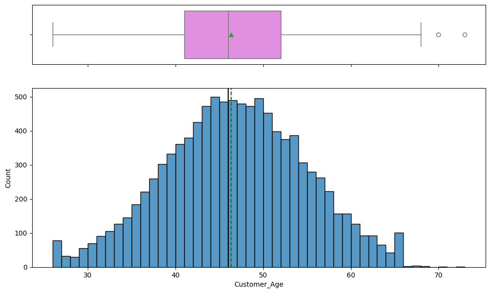

```python
#Plot Customer_Age
histogram_boxplot(data, "Customer_Age")
```

### Observation on Months On book

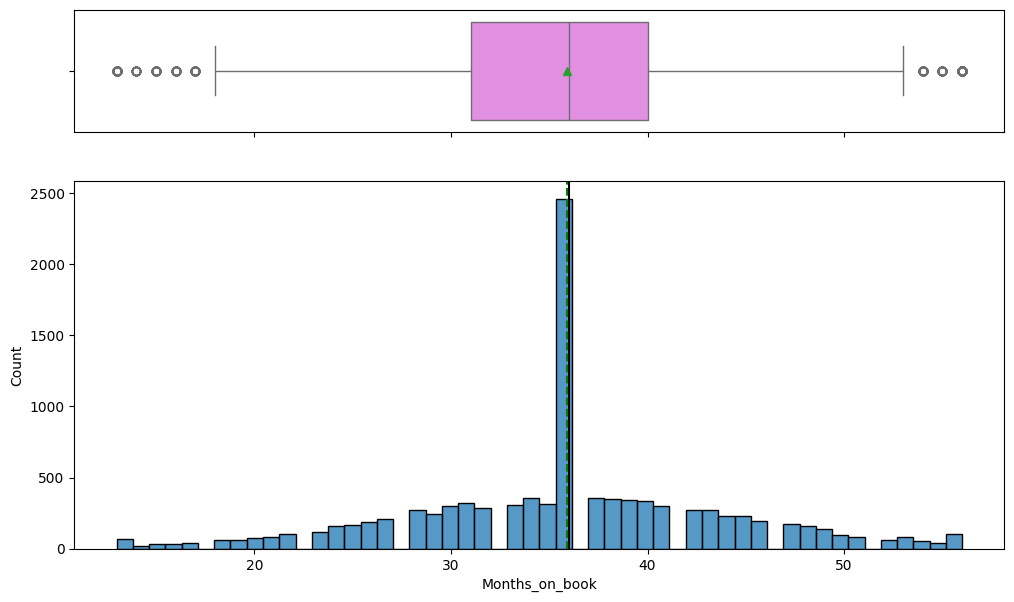

```python
histogram_boxplot(data, "Months_on_book")
```

- Months on book is a normal distribution
- There are few outliers but most of the customer have been in from 18th to 52 months
- It can also be seen that there are a very high no of customers (~2400) who's month on book is 36 months

### Observation on Credit Limit

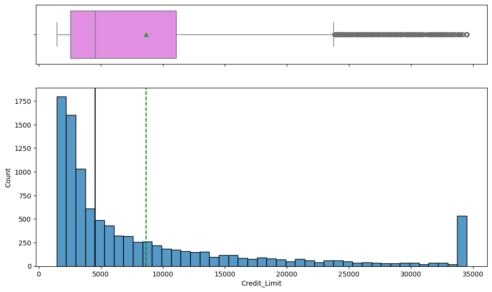

```python
histogram_boxplot(data, "Credit_Limit")
```

- Credit Limit is a right skewed ditribution
- Most customers have credit limits between 2k to 11k Dollars, however there are outliers beyond 24K credit limit

### Total Revolving Balance

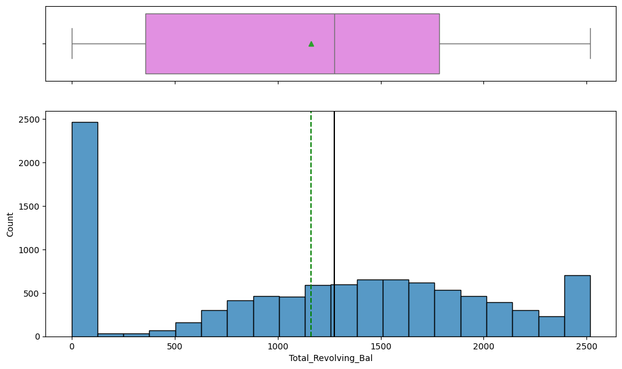

```python
histogram_boxplot(data, "Total_Revolving_Bal")
```

- The is a large no of customers who hae zero revolving balance- which means the pay on time
- max revolving credit limit is 2500$ and there are no outlier customers

```python
# No of customers with zero revolving balance
count_zero_revolving_balance=data['Total_Revolving_Bal'].value_counts().get(0, 0)
print(f"Number of rows with value '0' in 'Total_Revolving_Bal': {count_zero_revolving_balance}")
```

```
Number of rows with value '0' in 'Total_Revolving_Bal': 2470
```

- ~24% of the Customers have zero Total revolving balance

### Observations on Avg Open to buy Amount

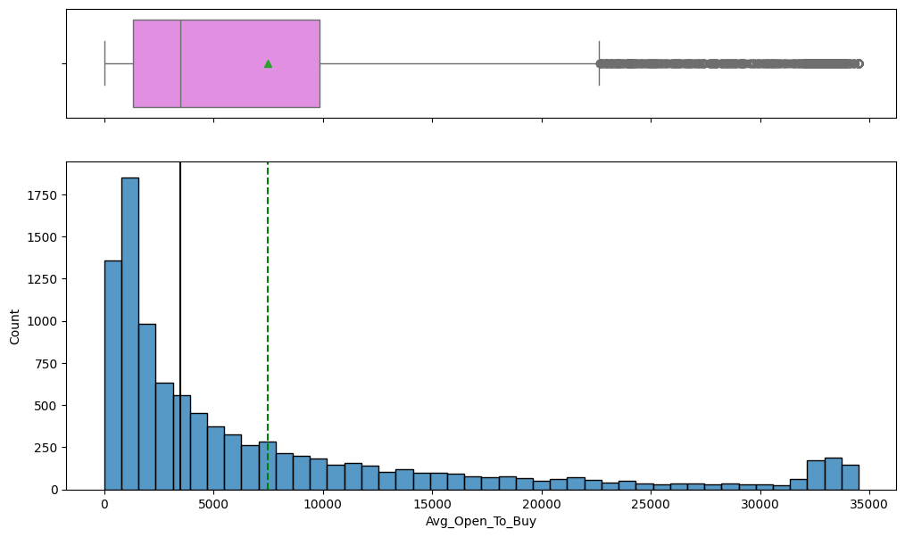

```python
histogram_boxplot(data, "Avg_Open_To_Buy")
```

- Avg Open to buy is a heavily right skewed distribution with 75% of customers having less than 10000 $ and 50% less than 3500
- There are outliers in the data for credit limit above 23000

### Observations on Total_Trans_Amt

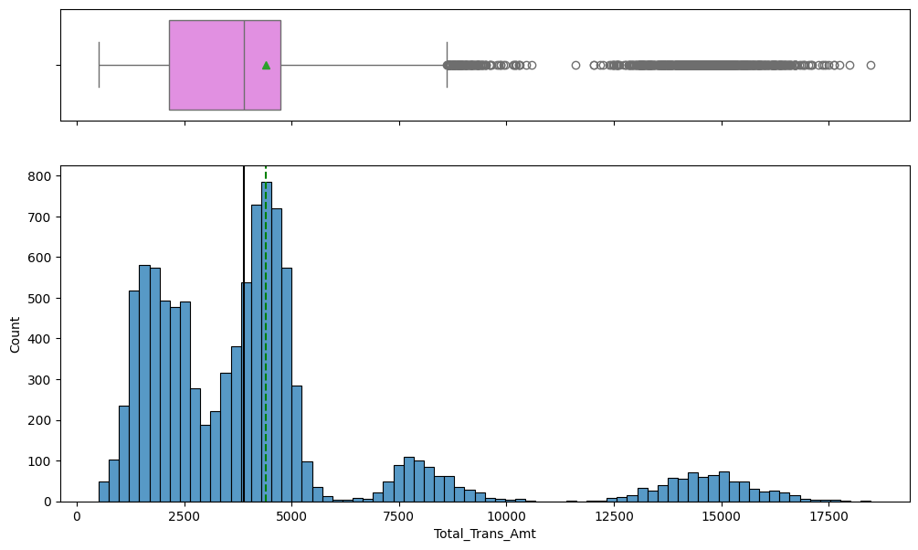

```python
histogram_boxplot(data, "Total_Trans_Amt")
```

- 50% of the customers have txn amout less than 3900
- There are a lot of outliers the data

### Observations on Total_Trans_Ct

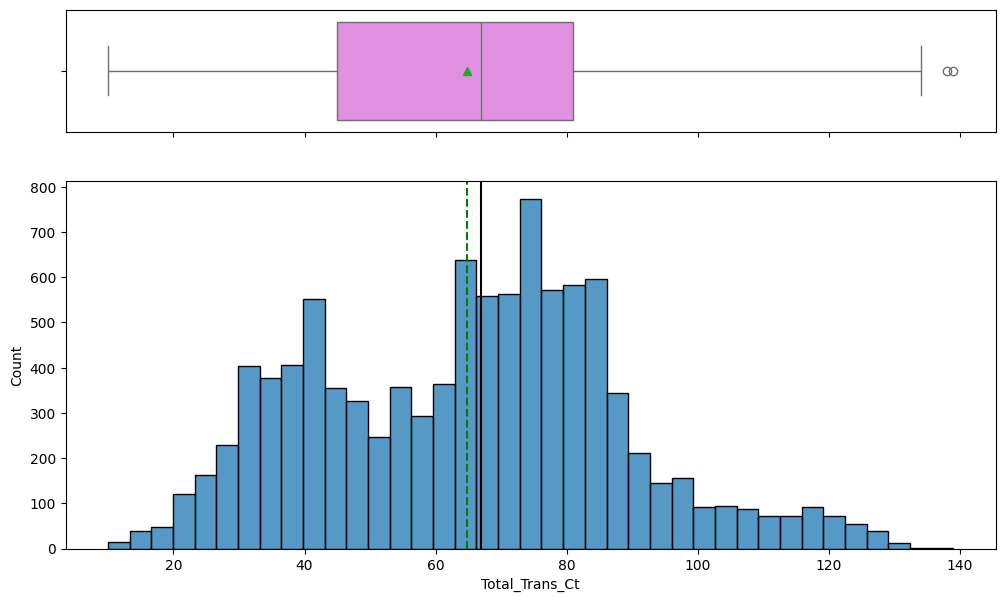

```python
histogram_boxplot(data, "Total_Trans_Ct")
```

- This is somewhat a normal distribution with just two outliers
- Cusomer density is higher (above 200) having transaction count ranging from 30 to 90
- We can also see that from Median(67 to 90 ) have the max customer density

### Observations on Total_Amt_Chng_Q4_Q1

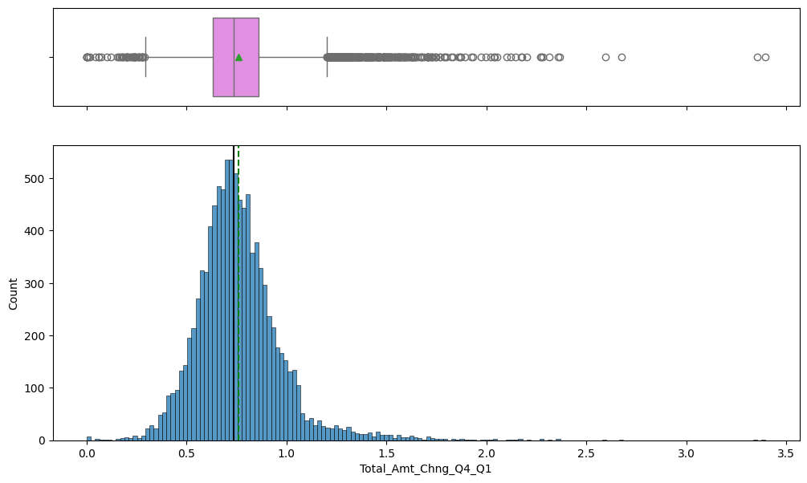

```python
histogram_boxplot(data, "Total_Amt_Chng_Q4_Q1")
```

### Observations on Total_Ct_Chng_Q4_Q1

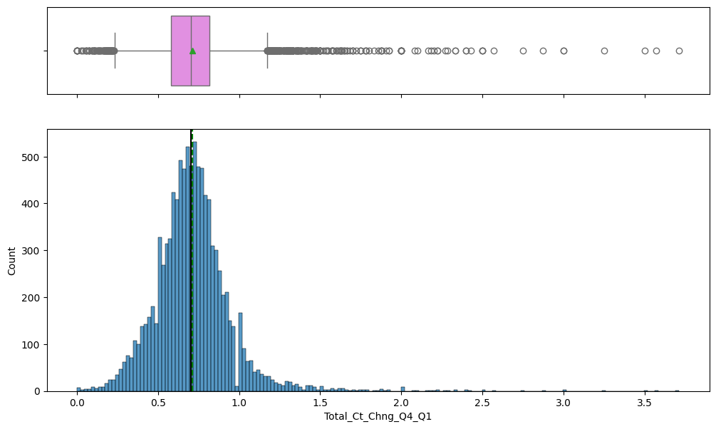

```python
histogram_boxplot(data, "Total_Ct_Chng_Q4_Q1")
```

### Observations on Avg_Utilization_Ratio

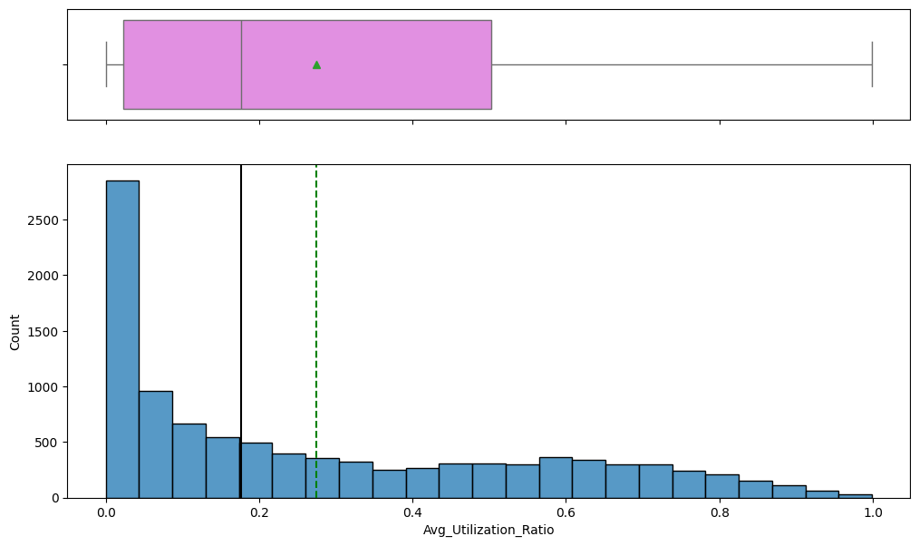

```python
histogram_boxplot(data, "Avg_Utilization_Ratio")
```

```python
#Customer count for customers with zero avg utilisation ratio
count_zero_avg_util_ratio=data['Avg_Utilization_Ratio'].value_counts().get(0, 0)
print(count_zero_avg_util_ratio)
```

```
2470
```

### Observations on Dependent Count

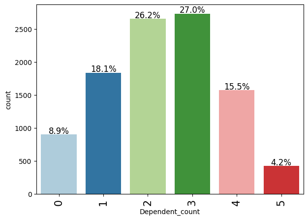

```python
labeled_barplot(df, "Dependent_count",perc=True)
```

- 27% of customers have 3 dependents closely followed by 26.2% customers having 2 dependents

### Observations on Total_Relationship_Count

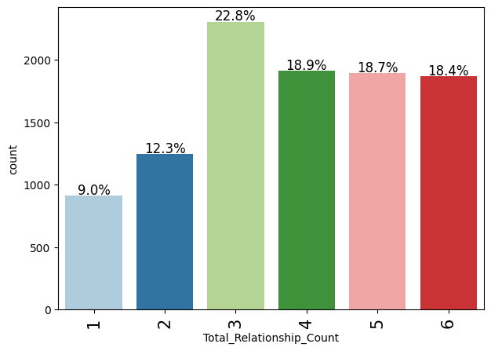

```python
labeled_barplot(df, "Total_Relationship_Count", perc=True)
```

### Observations on Months_Inactive_12_mon

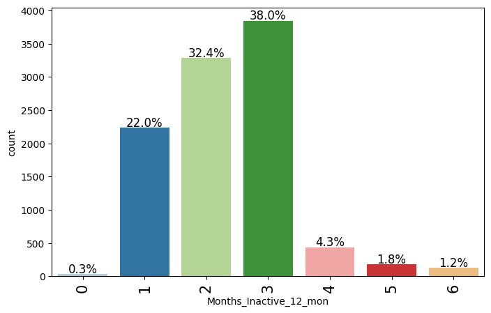

```python
labeled_barplot(data,"Months_Inactive_12_mon", perc=True)
```

### Observations on Contacts_Count_12_mon

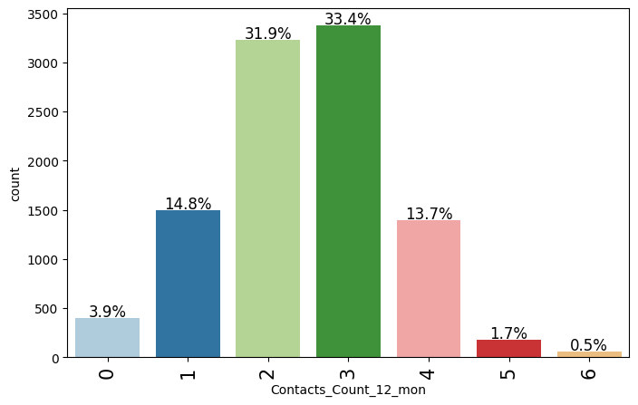

```python
labeled_barplot(data, "Contacts_Count_12_mon", perc=True)
```

- Almost 85% of the customers have 3 or lesser contacts with the bank in the last 12 months

## Bivariate Analysis

### Pair Plot

```python
sns.pairplot(data, hue = 'Attrition_Flag' , diag_kind='hist')
```

```
Output hidden; open in https://colab.research.google.com to view.
```

### Heatmap

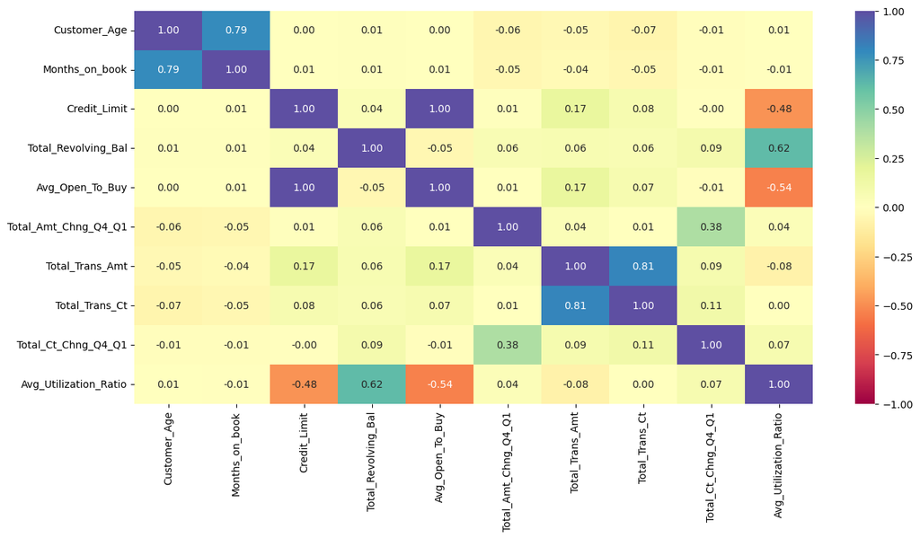

```python
plt.figure(figsize=(15, 7))
sns.heatmap(data.corr(numeric_only = True), annot=True, vmin=-1, vmax=1, fmt=".2f", cmap="Spectral")
plt.show()
```

- Positive Co-relations
- Total_trn_Ct and Total_Trn_Amount are strongly co-related(0.81)
  - The transaction amount increases with transaction count
- Customer_Age and Months on book are strongly co-related(0.79)
  - With increase in customer age, his months on book increases
- Total Revolving balance & Avg utilisation ratio have a co relation of (0.62)
  - increase in revolving balance results in increased avg utilisation ratio
- Negative co-relations
- Avg Open to Buy and Avg Utilisation ratio (-0.54)
  - Higher Open to Buy amount will result is lower utilisation ratio
- Credit Limit and Avg Utilisation ratio (-0.48)
  - As higher credit limit will have higher open to buy

### Attrition Flag with Dependent Count

```
Attrition_Flag   Attrited Customer  Existing Customer    All
Dependent_count
All                           1627               8500  10127
3                              482               2250   2732
2                              417               2238   2655
1                              269               1569   1838
4                              260               1314   1574
0                              135                769    904
5                               64                360    424
------------------------------------------------------------------------------------------------------------------------
```

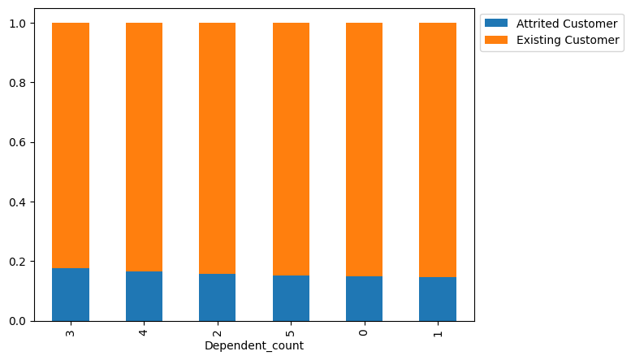

```python
stacked_barplot(df,"Dependent_count","Attrition_Flag")
```

- No visible impact of Dependent count on Attriting customers

### Attrition Flag with Total_Relationship_Count

```
Attrition_Flag            Attrited Customer  Existing Customer    All
Total_Relationship_Count
All                                    1627               8500  10127
3                                       400               1905   2305
2                                       346                897   1243
1                                       233                677    910
5                                       227               1664   1891
4                                       225               1687   1912
6                                       196               1670   1866
------------------------------------------------------------------------------------------------------------------------
```

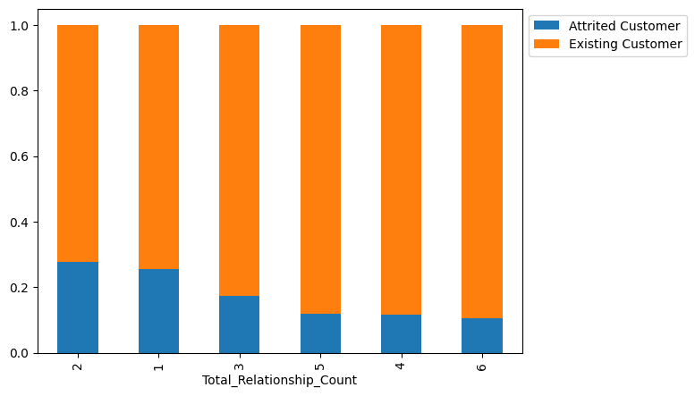

```python
stacked_barplot(data,"Total_Relationship_Count","Attrition_Flag")
```

### Attrition Flag with Months_Inactive_12_mon

```
Attrition_Flag          Attrited Customer  Existing Customer    All
Months_Inactive_12_mon
All                                  1627               8500  10127
3                                     826               3020   3846
2                                     505               2777   3282
4                                     130                305    435
1                                     100               2133   2233
5                                      32                146    178
6                                      19                105    124
0                                      15                 14     29
------------------------------------------------------------------------------------------------------------------------
```

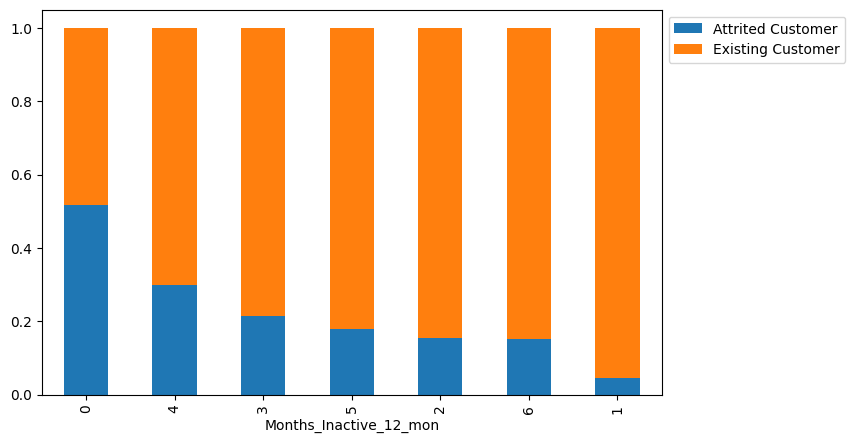

```python
stacked_barplot(data, "Months_Inactive_12_mon","Attrition_Flag")
```

### Attrition Flag with Contacts_Count_12_mon

```
Attrition_Flag         Attrited Customer  Existing Customer    All
Contacts_Count_12_mon
All                                 1627               8500  10127
3                                    681               2699   3380
2                                    403               2824   3227
4                                    315               1077   1392
1                                    108               1391   1499
5                                     59                117    176
6                                     54                  0     54
0                                      7                392    399
------------------------------------------------------------------------------------------------------------------------
```

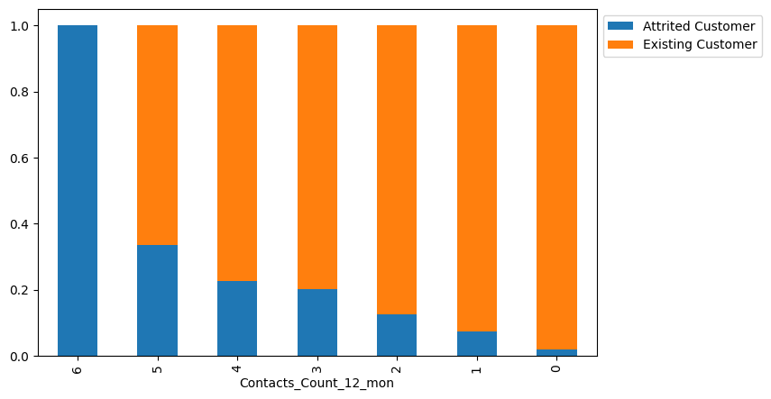

```python
stacked_barplot(data,"Contacts_Count_12_mon", "Attrition_Flag")
```

### Attrition Flag with Gender

```
Gender                F     M    All
Attrition_Flag
All                5358  4769  10127
Existing Customer  4428  4072   8500
Attrited Customer   930   697   1627
------------------------------------------------------------------------------------------------------------------------
```

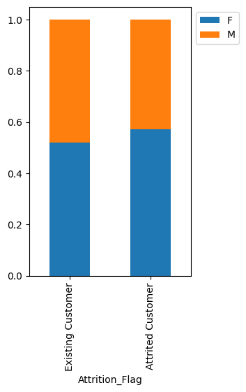

```python
stacked_barplot(data,"Attrition_Flag","Gender")
```

- Gender has no significant impact on attrition

### Attrition Flag with Education_Level

```
Attrition_Flag   Attrited Customer  Existing Customer   All
Education_Level
All                           1371               7237  8608
Graduate                       487               2641  3128
High School                    306               1707  2013
Uneducated                     237               1250  1487
College                        154                859  1013
Doctorate                       95                356   451
Post-Graduate                   92                424   516
------------------------------------------------------------------------------------------------------------------------
```

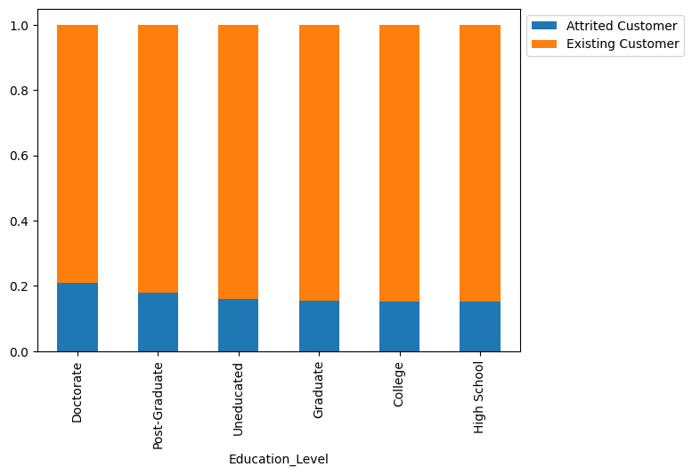

```python
stacked_barplot(data,"Education_Level","Attrition_Flag")
```

- No visible relation between education level and attrition

### Attrition Flag with Marital_Status

```
Attrition_Flag  Attrited Customer  Existing Customer   All
Marital_Status
All                          1498               7880  9378
Married                       709               3978  4687
Single                        668               3275  3943
Divorced                      121                627   748
------------------------------------------------------------------------------------------------------------------------
```

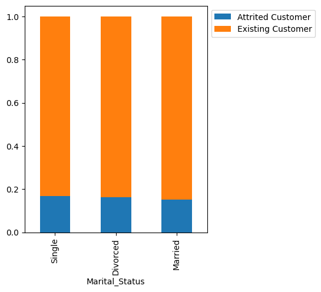

```python
stacked_barplot(data,"Marital_Status","Attrition_Flag")
```

- No signification relation of Marital_Status with Attrition

### Attrition Flag with Income Category

```
Attrition_Flag   Attrited Customer  Existing Customer    All
Income_Category
All                           1627               8500  10127
Less than $40K                 612               2949   3561
$40K - $60K                    271               1519   1790
$80K - $120K                   242               1293   1535
$60K - $80K                    189               1213   1402
Undisclosed                    187                925   1112
$120K +                        126                601    727
------------------------------------------------------------------------------------------------------------------------
```

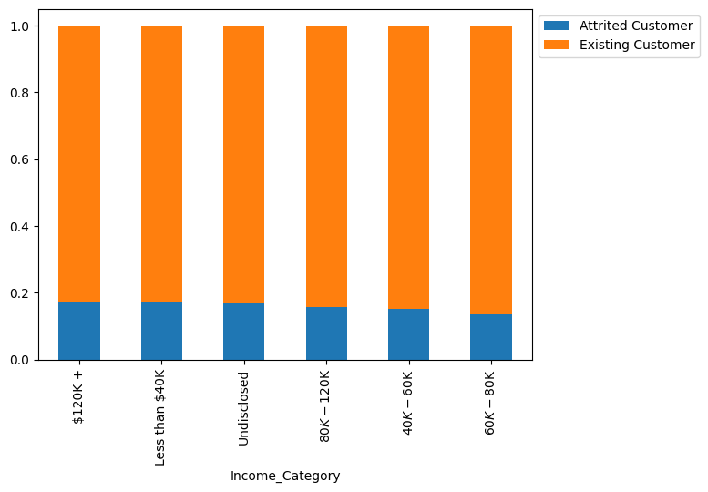

```python
stacked_barplot(data,"Income_Category","Attrition_Flag")
```

- No significant impact of Salary Category on attrition

### Attrition Flag Vs Card Category

```
Attrition_Flag  Attrited Customer  Existing Customer    All
Card_Category
All                          1627               8500  10127
Blue                         1519               7917   9436
Silver                         82                473    555
Gold                           21                 95    116
Platinum                        5                 15     20
------------------------------------------------------------------------------------------------------------------------
```

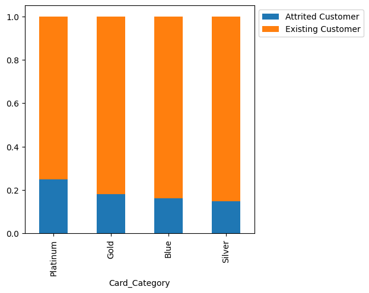

```python
stacked_barplot(data,"Card_Category","Attrition_Flag")
```

- There is no visible co relation b/w gender, Eductaion_Level, Maital_Status, Icome_Category and Card_Category with Attrition_Flag

### Distrubition wrt target variable

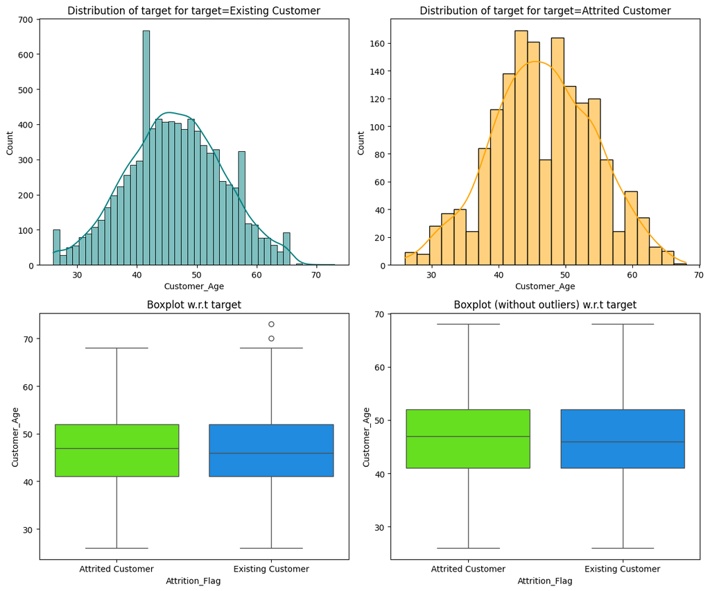

```python
distribution_plot_wrt_target(data, "Customer_Age", "Attrition_Flag")
```

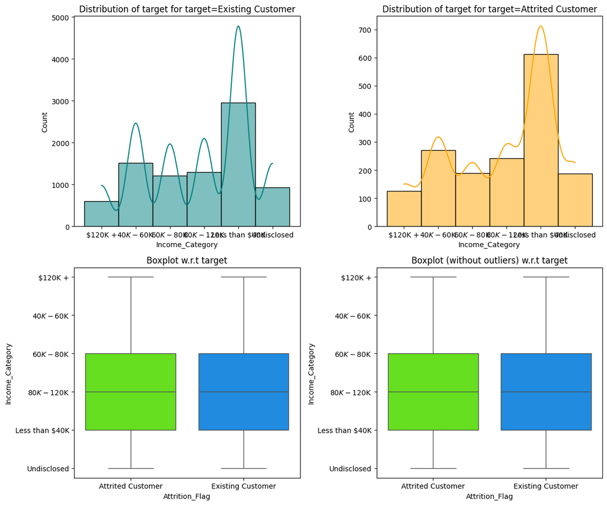

```python
distribution_plot_wrt_target(data, "Income_Category", "Attrition_Flag")
```

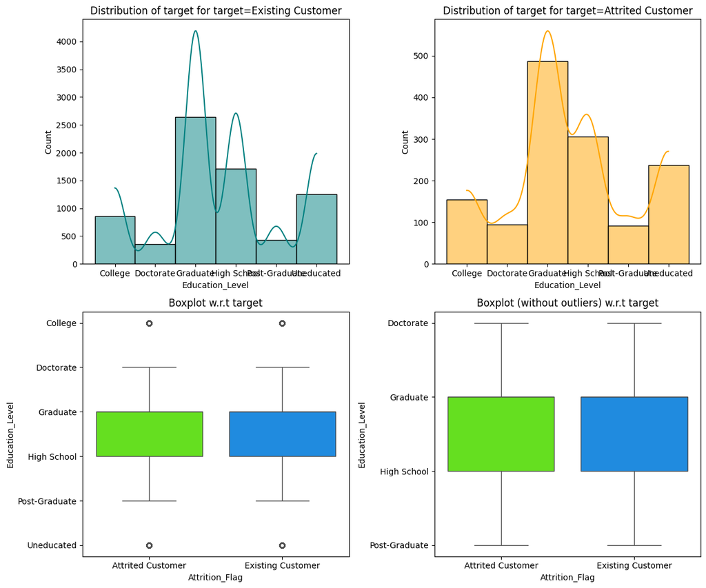

```python
distribution_plot_wrt_target(data,"Education_Level" , "Attrition_Flag")
```

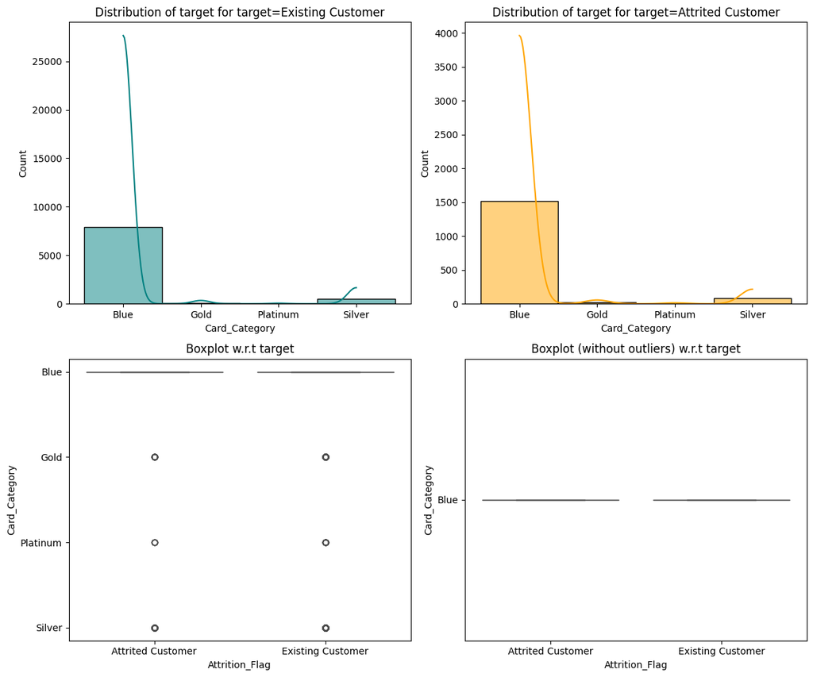

```python
distribution_plot_wrt_target(data, "Card_Category", "Attrition_Flag")
```

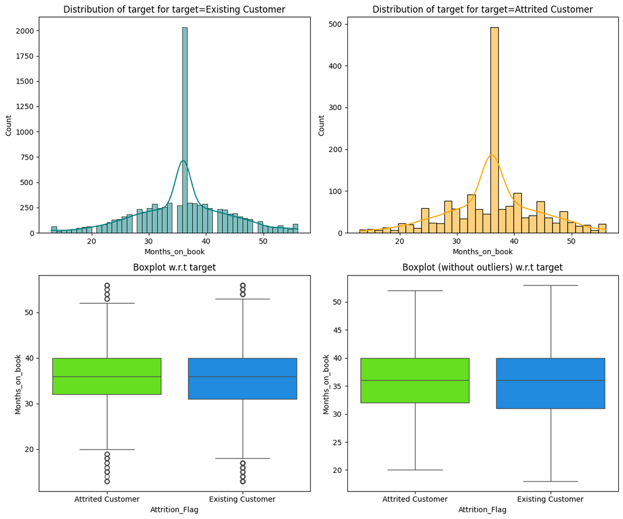

```python
distribution_plot_wrt_target(data, "Months_on_book", "Attrition_Flag")
```

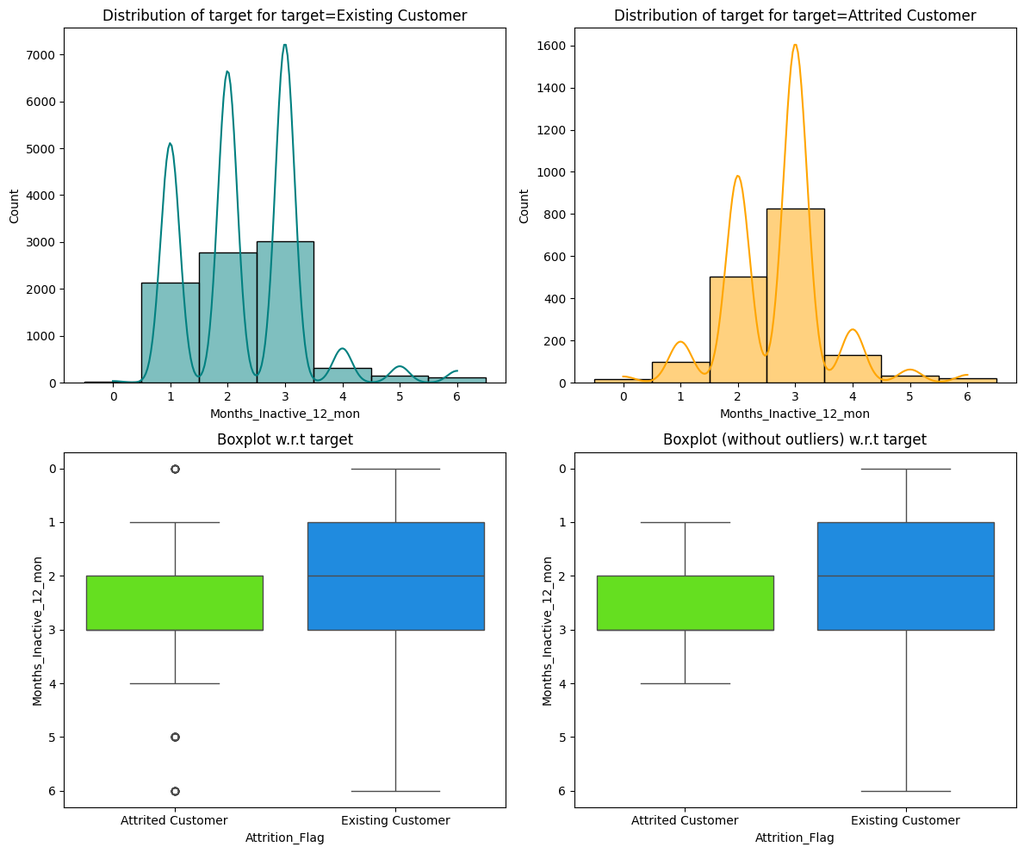

```python
distribution_plot_wrt_target(data, "Months_Inactive_12_mon", "Attrition_Flag")
```